[figure not shown]

# Predicting Question Response Times on Stack Overflow

# Introduction

Stack Overflow is a question and answer site for all levels of programmers. As one of the most popular communities for learning and sharing knowledge about computer science, Stack Overflow boasts over 50 million monthly visitors, hosting a database of roughly 20 million questions. The platform works as follows: Users with a question will make an initial post with a title, their question, and some tags that categorize their question according to broad topics (such as programming language, data structure, or etc.). Other users can than view these questions and post an answer. At any point in time, users can vote on both the question and answers, according to whether or not the question is well-researched or the the answer is useful.

Because of the magnitude of questions that are posted on a daily basis, one aspect of interest is how quickly an answer to a given question will be posted. If a question is posed in a certain way, will it result in more or faster answers? Consider the following: By posting a question with an overly complex title or body, users might be less willing to put in the effort to answer the question. Consider another scenerio: If a question is not posted with the appropriate tags, or even too little tags, it might not reach or be exposed to the correct audience, also resulting in a slower response time.

Since 2009, Stack Overflow's data has been publicly available under the Creative Commons BY-SA 3.0 License. In this tutorial, my goal is to organize the data given in the data "dump", provide some insight into the factors that most influence the time taken for an answer to be posted for a given question, and predict response time when a question is posted with certain attributes.

# Getting the Data

As I mentioned, Stack Overflow's record of questions and answers is publicly accessible and hosted on [Internet Archive](https://archive.org/details/stackexchange). However, there are a number of reasons that make this source undesirable: 20 million questions results in a massive file that takes exhorbitant amounts of time simply to load and parse, these questions range all the way from the beginning of Stack Overflow's opening and thus may not represent the modern community, and such a source contains lots of extraneous data that is irrelevant for our goals. Luckily, Stack Exchange (Stack Overflow's parent company) provides a [web-based data explorer](https://data.stackexchange.com/stackoverflow/query/new) that can be used to query (via SQL) and extract portions of the data.

Looking at the [format](https://ia800107.us.archive.org/27/items/stackexchange/readme.txt) of the data, questions and answers are stored under a single table, called Posts, with questions having a PostTypeId of 1 and answers, 2. Furthermore, question and answers have a form of foreign-key relation: If PostTypeId is 2 (meaning the post represents an answer), then the row will have a ParentId equal to the Id of the question that it is answering. Moreover, each question can have multiple answers. For simplicty, we will only look at the fastest answer. Finally, in order to get an accurate representation of the community, will only look at more modern questions. Thus, we will need to construct a query that:

- Matches questions with their answers based on the ParentId-Id relationship
- Extracts relevant information, such as the time and date of posting, for both the question and answer
- Limits our extraction to only questions after 2016 (a delimiter for 'modern' questions estimated through observation of the data)

The following query will perform accomplish this using subqueries and windowed functions

```
        SELECT  q.Id, q.Title, q.Body, q.Tags, q.CreationDate as QuestionDate,
        a2.CreationDate as AnswerDate
        FROM    Posts q
        INNER JOIN
                (
                SELECT  a.Id, a.CreationDate, a.ParentId, ROW_NUMBER()
                        OVER (PARTITION BY a.ParentId ORDER BY a.CreationDate) AS RowNum
                FROM    Posts a

                ) a2 ON a2.ParentId = q.Id And RowNum = 1
        WHERE q.CreationDate > Convert(datetime, '2016-12-31' )
```

Input this query into the data explorer and download the resulting csv file

# Getting Started with the Data

We will use Python 3 and start by importing a few libraries (descriptions listed)

```python
!pip install category_encoders
```

```
     |████████████████████████████████| 102kB 1.5MB/s ta 0:00:01
```

```python
import pandas as pd
import numpy as np
import matplotlib.pyplot as plt
from datetime import datetime, timedelta # parsing and substracting dates
from decimal import Decimal # computation of large floats for geometric mean
from scipy.stats import f, mstats
from scipy import stats
import seaborn as sns
from sklearn.model_selection import train_test_split
from sklearn.linear_model import LinearRegression
from sklearn.preprocessing import LabelEncoder
from sklearn.metrics import mean_squared_error
from sklearn.neighbors import KNeighborsRegressor
import statsmodels.formula.api as smf
import category_encoders as ce
import warnings
warnings.filterwarnings('ignore')
```

Then, let's read in our extracted csv file and view its contents

```python
so = pd.read_csv("stackoverflow.csv")
so.shape
```

```
(50000, 6)
```

```python
so.head()
```

|  | Id | Title | Body | Tags | QuestionDate | AnswerDate |
| --- | --- | --- | --- | --- | --- | --- |
| 0 | 41404220 | what can be a statement after if? | <pre><code>def check():\n if [1,2,3]:\n ... | <python><if-statement> | 2016-12-31 00:01:40 | 2016-12-31 00:05:51 |
| 1 | 41404236 | How do I Inner Join users table with followed ... | <p>I am trying to retrieve the posts from the ... | <php><mysql> | 2016-12-31 00:04:22 | 2016-12-31 00:17:53 |
| 2 | 41404216 | Android send curl request to Heroku with option | <p>Using Android, I am trying to send a curl r... | <android><curl><heroku><httpclient> | 2016-12-31 00:01:15 | 2016-12-31 00:14:14 |
| 3 | 41404232 | React TransitionGroup and React.cloneElement d... | <p>I am following Chang Wang's tutorial for ma... | <reactjs><animation><redux><react-router><reac... | 2016-12-31 00:03:17 | 2016-12-31 06:03:28 |
| 4 | 41404242 | How to access the outer caller in nested forEach | <p>I'm learning <a href="https://developer.moz... | <javascript><arrays><foreach> | 2016-12-31 00:05:25 | 2016-12-31 00:09:37 |

In the above dataframe, there are 6 columns:

- Id: the unique identifier for each questions
- Title: the title of the question
- Body: the larger text representing the body or actual question
- Tags: the series of tags that a question was posted with; these classify the question as described before
- QuestionDate: The exact date and time at which the question was first posted
- AnswerDate: The exact date and time at which the *first* answer to the given question was posted

# Preprocessing

Before we can begin analyzing our data, we will need to tidy it and extract important pieces of information. This will include items such computing the time difference between QuestionDate and AnswerDate and extracting a list of tags for each question

The first thing we will do is extract the time taken to respond to a question: First, the QuestionDate and AnswerDate fields are stored as strings representing the SQL datetime format: YYYY-MM-DD HH:MI:SS. The process is then simply to parse the date from each string and substract them using python's datetime library. For simplicity and ease of later computation, the time difference will be stored in terms of minutes

```python
# Given a row, this method will parse the QuestionDate and AnswerDate fields and return the substracted time
def mapDateAndSubtract(row):

    # use strptime to convert string to datetime object

    QuestionTime = datetime.strptime(row['QuestionDate'], "%Y-%m-%d %H:%M:%S")

    AnswerTime = datetime.strptime(row['AnswerDate'], "%Y-%m-%d %H:%M:%S")

    return Decimal((AnswerTime - QuestionTime).total_seconds() / 60)


# Map dataframe to create time difference column, time_diff
so['time_diff'] = so.apply (mapDateAndSubtract, axis=1)
so.head()
```

|  | Id | Title | Body | Tags | QuestionDate | AnswerDate | time_diff |
| --- | --- | --- | --- | --- | --- | --- | --- |
| 0 | 41404220 | what can be a statement after if? | <pre><code>def check():\n if [1,2,3]:\n ... | <python><if-statement> | 2016-12-31 00:01:40 | 2016-12-31 00:05:51 | 4.18333333333333357018091192003339529037475585... |
| 1 | 41404236 | How do I Inner Join users table with followed ... | <p>I am trying to retrieve the posts from the ... | <php><mysql> | 2016-12-31 00:04:22 | 2016-12-31 00:17:53 | 13.5166666666666674956331917201168835163116455... |
| 2 | 41404216 | Android send curl request to Heroku with option | <p>Using Android, I am trying to send a curl r... | <android><curl><heroku><httpclient> | 2016-12-31 00:01:15 | 2016-12-31 00:14:14 | 12.9833333333333325043668082798831164836883544... |
| 3 | 41404232 | React TransitionGroup and React.cloneElement d... | <p>I am following Chang Wang's tutorial for ma... | <reactjs><animation><redux><react-router><reac... | 2016-12-31 00:03:17 | 2016-12-31 06:03:28 | 360.18333333333333712289459072053432464599609375 |
| 4 | 41404242 | How to access the outer caller in nested forEach | <p>I'm learning <a href="https://developer.moz... | <javascript><arrays><foreach> | 2016-12-31 00:05:25 | 2016-12-31 00:09:37 | 4.20000000000000017763568394002504646778106689... |

The next thing we will do is extract the tags as a list of strings. Currently, the tags are represented as a single string as follows: "<tag #1><tag #2>...". The process of extraction will simply be to remove the outermost angled brackets and split the resulting string

```python
def mapTags(tag):
    tags = []

    # at least one tag - safety measure for general purposes: no row in current dataset has zero tags
    if(len(tag) != 0):
        tags = tag[1:-1].split("><")

    return tags

so['tag_list'] = so['Tags'].apply(mapTags)
so.head()
```

|  | Id | Title | Body | Tags | QuestionDate | AnswerDate | time_diff | tag_list |
| --- | --- | --- | --- | --- | --- | --- | --- | --- |
| 0 | 41404220 | what can be a statement after if? | <pre><code>def check():\n if [1,2,3]:\n ... | <python><if-statement> | 2016-12-31 00:01:40 | 2016-12-31 00:05:51 | 4.18333333333333357018091192003339529037475585... | [python, if-statement] |
| 1 | 41404236 | How do I Inner Join users table with followed ... | <p>I am trying to retrieve the posts from the ... | <php><mysql> | 2016-12-31 00:04:22 | 2016-12-31 00:17:53 | 13.5166666666666674956331917201168835163116455... | [php, mysql] |
| 2 | 41404216 | Android send curl request to Heroku with option | <p>Using Android, I am trying to send a curl r... | <android><curl><heroku><httpclient> | 2016-12-31 00:01:15 | 2016-12-31 00:14:14 | 12.9833333333333325043668082798831164836883544... | [android, curl, heroku, httpclient] |
| 3 | 41404232 | React TransitionGroup and React.cloneElement d... | <p>I am following Chang Wang's tutorial for ma... | <reactjs><animation><redux><react-router><reac... | 2016-12-31 00:03:17 | 2016-12-31 06:03:28 | 360.18333333333333712289459072053432464599609375 | [reactjs, animation, redux, react-router, reac... |
| 4 | 41404242 | How to access the outer caller in nested forEach | <p>I'm learning <a href="https://developer.moz... | <javascript><arrays><foreach> | 2016-12-31 00:05:25 | 2016-12-31 00:09:37 | 4.20000000000000017763568394002504646778106689... | [javascript, arrays, foreach] |

# Exploratory Data Analysis

We can now begin analyzing some basic properties of the date

Let's start by getting the average response time for some popular tags:

```python
# helper function to format time difference (i.e. convert seconds to days, minutes, etc...)
def pretty_print_time(df):
    curdf = df.copy()
    curdf[('time_diff', 'avg')] = curdf[('time_diff', 'avg')].apply(lambda x: timedelta(seconds=float(x)*60))
    return curdf
```

```python
popular = so.explode('tag_list') # create a new row for every existing row with one tag in each
aggre = popular[['time_diff','tag_list']].groupby('tag_list').agg([lambda x: x.mean(), 'count']) # groupby tag and aggregate
aggre.columns.set_levels(['avg','count'],level=1,inplace=True) # rename columns
# popular tags
pretty_print_time(aggre.loc[['javascript', 'java', 'c#', 'php', 'python', 'android', 'jquery', 'html', 'perl', 'rust']])
```

| tag_list | time_diff avg | time_diff count |
| --- | --- | --- |
| javascript | 7 days 21:04:00.183925 | 6171 |
| java | 9 days 15:44:51.613500 | 4000 |
| c# | 8 days 23:52:09.494881 | 3223 |
| php | 7 days 16:56:27.271612 | 3586 |
| python | 11 days 21:01:58.066534 | 4028 |
| android | 14 days 01:59:33.481716 | 3637 |
| jquery | 3 days 22:13:07.322782 | 2401 |
| html | 4 days 04:35:17.291076 | 2824 |
| perl | 0 days 09:04:45.526316 | 114 |
| rust | 20 days 02:41:59.821429 | 84 |

However, these numbers look very skewed in comparison to reality. Let's try taking a geometric mean instead of an arithmetic mean:

```python
def geo_mean(sr):
    sr_temp = sr[sr != 0]

    try:
        pr = sr_temp.product()
        over = Decimal(1)/Decimal(len(sr_temp))
        return Decimal(pr)**(Decimal(over))
    except:
        return 0


aggre2 = popular[['time_diff','tag_list']].groupby('tag_list').agg({'time_diff':[geo_mean, 'count']}) # groupby tag and aggregate
aggre2.columns.set_levels(['avg','count'],level=1,inplace=True) # rename columns
# popular tags
pretty_print_time(aggre2.loc[['javascript', 'java', 'c#', 'php', 'python', 'android', 'jquery', 'html', 'perl', 'rust']])
```

| tag_list | time_diff avg | time_diff count |
| --- | --- | --- |
| javascript | 00:41:53.178257 | 6171 |
| java | 01:09:17.553080 | 4000 |
| c# | 01:04:19.532371 | 3223 |
| php | 00:46:12.394996 | 3586 |
| python | 00:55:38.897536 | 4028 |
| android | 01:18:42.132690 | 3637 |
| jquery | 00:27:40.804246 | 2401 |
| html | 00:23:56.150646 | 2824 |
| perl | 00:39:27.400805 | 114 |
| rust | 01:39:46.785530 | 84 |

This looks a little more accurate

At this point there are several questions we would like to answer:

- Do key question words (how, why, which) differ in response times?
- Does it take less time to get a response on certain days of the week?
- Does it take less time to get a response at certain times (1 AM vs 1 PM)?
- Do shorter questions get a faster reply than longer questions?
- etc...

We will try and explore some of these

Let's start by looking at questions by some keywords: "why", "how", "what", "is", "where", "when", "which", "can".

When certain keywords are, the general format of the response changes. For example, a question with the word "when" in it might suggest the user is asking for a specific date (example: "when will Python 4 be released?"). As a result, users might take longer or shorter times to answer a given question. Something as simple as a yes or no question might be answered faster than a question that asks for a procedure or methodology

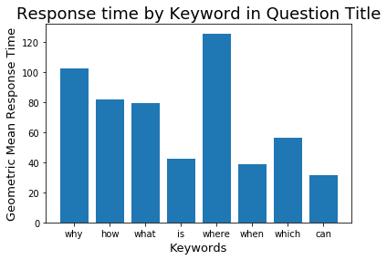

```python
keywords = ["why", "how", "what", "is", "where", "when", "which", "can"]

def get_grp(x, df, col_name, my_list):
    for c in my_list:
        if c in df[col_name][x]:
            return c

fig = plt.figure()

keywords_df = so.groupby(lambda x : get_grp(x, so, 'Title', keywords)).agg({'time_diff': [lambda x: geo_mean(x), 'count']})
keywords_df.columns.set_levels(['avg','count'],level=1,inplace=True) # rename columns
h = keywords_df['time_diff']['avg'].astype('float')
plt.bar(x=list(range(8)), height = h)
plt.title('Response time by Keyword in Question Title', fontsize=18)
plt.ylabel('Geometric Mean Response Time', fontsize=13)
plt.xlabel('Keywords', fontsize=13)
plt.xticks(list(range(8)), keywords);
```

The next metric we should look at is the size of the title and question at hand. Longer titles might indicate a more complex question, while shorter titles might suggest a simpler, easier-to-answer question. The opposite might also be true: If a question is longer, it might be more specific and detailed, asking for an exact answer, while a shorter question might be too vague and thus not answered.

Let's start with the length of the title

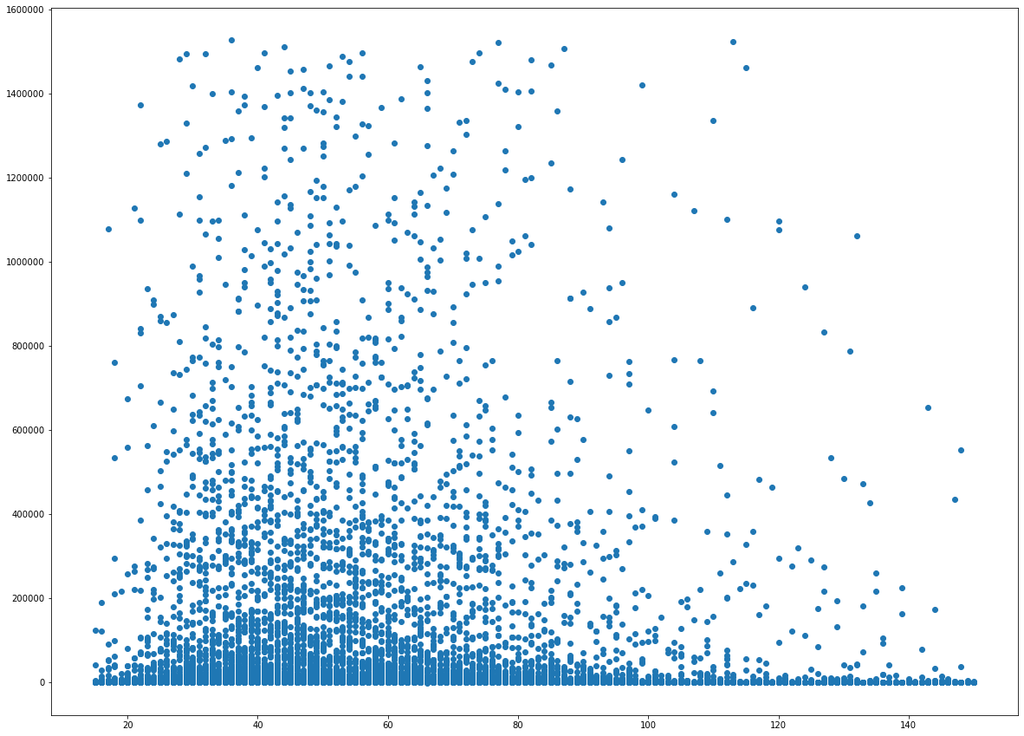

```python
# compute length of each title
so['title_length'] = so['Title'].apply(len)
# filter zero response times
nonzero = so[so['title_length'] != 0]
# plot
plt.figure(figsize=(20, 15))
plt.scatter(x=nonzero["title_length"], y=nonzero["time_diff"].astype('float'))
```

A number of things seem to be going on: First, a significant portion of the data seems to be clustered around the bottom-left region. This region indicates questions with small titles and low response times. There also seems to be a number of points representing short titles with very long response times, much more than points with long titles and long response times. This conflicting data suggests that looking at the title length in isolation is not very informative.

Let's try the same procedure with question length

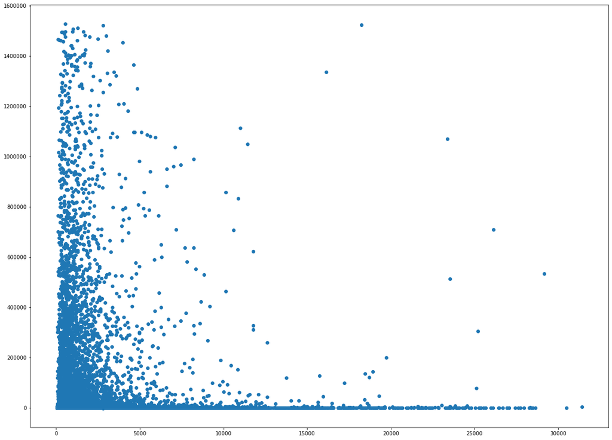

```python
# compute length of each title
so['body_length'] = so['Body'].apply(len)
# filter zero response times
nonzero = so[so['body_length'] != 0]
# plot
plt.figure(figsize=(20, 15))
plt.scatter(x=nonzero["body_length"], y=nonzero["time_diff"].astype('float'))
```

The next metric is the exact time and date at which the question was posted. If Stack Overflow user activity is more hot during the day, a question posted at midnight might recieve less attention and thus result in longer response times. The same scenario can be reflected on the day of the week. If users are more active during the work week, a question posted on the weekend might recieve a longer response time for the same reason. These are simply speculations to show the value in looking at these metrics and do not necessarily reflect reality.

Let's start with time of day. These easiest way to see this is to place questions into buckets representing ranges of times. For example, bucket 1 will represent 12 AM - 1 AM, bucket 2 will repreesnt 1 AM - 2 AM, and so on, resulting in 24 buckets.

```python
# extract hour to be used as bucket
def extractHour(row):

    # use strptime to convert string to datetime object

    QuestionTime = datetime.strptime(row['QuestionDate'], "%Y-%m-%d %H:%M:%S")

    return QuestionTime.hour

so['question_hour'] = so.apply(extractHour, axis=1)
```

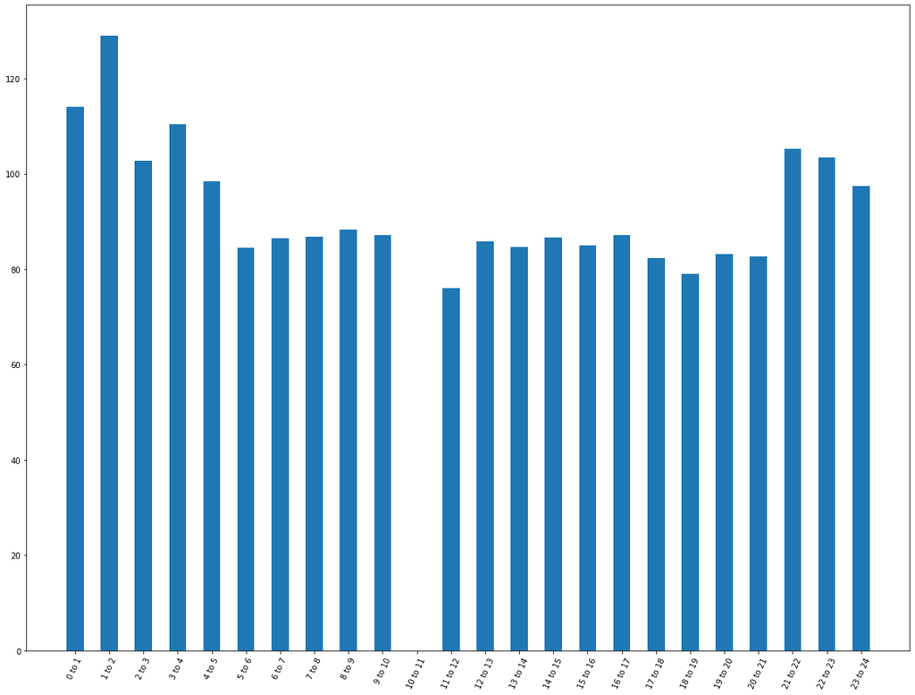

```python
so['hour_bin'], bins = pd.cut(so['question_hour'], bins=list(range(-1,24)), include_lowest=True, retbins=True) # seperate into bins
time_df = so[['time_diff', 'hour_bin']].groupby('hour_bin').agg({'time_diff': [geo_mean, 'count']})
plt.figure(figsize=(20, 15))
plt.bar(range(len(time_df)),time_df['time_diff']['geo_mean'], width=0.5)
bins_str = list(map(lambda x: str(x+1) + " to " + str(x+2), bins))
plt.xticks(range(len(time_df)), bins_str, rotation=65);
```

The above plot shows the geometric mean for questions posted in each time frame of exactly 1 hour. Unfortunately, the computation for 10 AM - 11 AM caused an overflow (i.e. the number resulting in the product was too large). However, it can be seen that questions posted frim 11-12 AM show the fastest response times while questions posted from 1 AM to 2 AM show the longest response times.

We can repeat this procedure for day of the week. This time we will bucket questions based on when they are posted: Monday, Tuesday, etc...

```python
# extract day to be used as bucket
def extractDay(row):

    # use strptime to convert string to datetime object

    QuestionTime = datetime.strptime(row['QuestionDate'], "%Y-%m-%d %H:%M:%S")

    return QuestionTime.weekday()

so['question_day'] = so.apply(extractDay, axis=1)
```

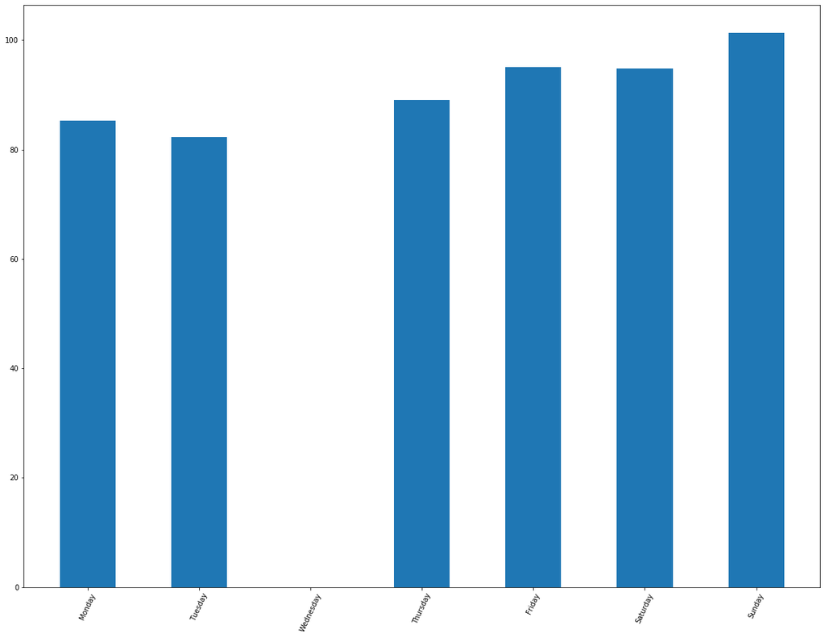

```python
day_df = so[['time_diff', 'question_day']].groupby('question_day').agg({'time_diff': [geo_mean, 'count']})
plt.figure(figsize=(20, 15))
plt.bar(range(len(day_df)), day_df['time_diff']['geo_mean'], width=0.5)
bins_str = ["Monday", "Tuesday", "Wednesday", "Thursday", "Friday", "Saturday", "Sunday"]
plt.xticks(list(range(len(day_df))), bins_str, rotation=65);
```

The above plot shows the geometric mean for questions posted on each day of the week. Unfortunately, the computation for Wednesday caused an overflow (i.e. the number resulting in the product was too large). However, it can be seen that questions posted on Tuesday received the lowest response times while questions posted on Sunday resulted in the longest response times.

# Predicting Response Times

In this last section, we will develop a model to predict the response times given a question and its various attributes discussed above. Specifically, we will develop a linear regression as well as a K-nearest neighbors (KNN) regression to predict the time in minutes that a given question will take to receieve a response.

We will start by only taking the parameters we need:

```python
X = so.explode('tag_list').drop(['Id', 'Title', 'Body', 'Tags', 'QuestionDate', 'AnswerDate', 'hour_bin'], axis=1)
y = X['time_diff'].astype('float')
X = X.drop(['time_diff'], axis=1)
```

Next, both regression models requires numerical features. Thus, in order to encode the string representing the tag(s) for each question, we will use feature hashing (Other techniques such as one-hot encoding would not work well because the number of unique tags is very high, which result in a large number of features and slow performance). We will use the Category Encoders module, a subdivision of the sklearn library

```python
encoder = ce.HashingEncoder(cols=['tag_list'])
X = encoder.fit_transform(X, y)
X.head()
```

|  | col_0 | col_1 | col_2 | col_3 | col_4 | col_5 | col_6 | col_7 | title_length | body_length | question_hour | question_day |
| --- | --- | --- | --- | --- | --- | --- | --- | --- | --- | --- | --- | --- |
| 0 | 0 | 0 | 0 | 0 | 0 | 1 | 0 | 0 | 33 | 280 | 0 | 5 |
| 0 | 1 | 0 | 0 | 0 | 0 | 0 | 0 | 0 | 33 | 280 | 0 | 5 |
| 1 | 0 | 0 | 0 | 0 | 1 | 0 | 0 | 0 | 58 | 2454 | 0 | 5 |
| 1 | 0 | 0 | 0 | 0 | 0 | 0 | 1 | 0 | 58 | 2454 | 0 | 5 |
| 2 | 1 | 0 | 0 | 0 | 0 | 0 | 0 | 0 | 47 | 1605 | 0 | 5 |

Next, we will split our data into sets for training and learning. The testing portion will be roughly 1/4 of the total dataset and the data will be shuffled before it is divided.

```python
X_train, X_test, y_train, y_test = train_test_split(X, y)
```

Finally, we will train our linear model on the data

```python
reg = LinearRegression().fit(X_train, y_train)
```

We will also train our K-nearest neighbors regression

```python
# KNN regression
neigh = KNeighborsRegressor(n_neighbors=2).fit(X_train, y_train)
```

We then evaluate our models in two ways: First using a generic mean squared error (MSE). Second using the coefficient of determination, or r-squared, measure.

MSE simply takes the arithmetic mean of the squared difference between the predicted vector and the actual vector. We will again use the sklearn package to accomplish this. The R^2 statistic, which exists in the range 0 - 1, represents the proportion of variance in the dependent variable that is explainable by the independent variable(s). A value closer to 1 will indicate that the variance in the response times is explainable by the features discussed above.

Evaluating the linear regression:

```python
# use linear regression to predict
pred = reg.predict(X_test)
```

```python
# linear regression

# MSE
print("Mean Squared Error: " + str(mean_squared_error(y_test, pred)))

# R-Squared
print("R^2 Value: " + str(reg.score(X_test, y_test)))
```

```
Mean Squared Error: 12425960106.852112
R^2 Value: 0.0011859187895162382
```

Evaluating the KNN regression:

```python
# use KNN regression to predict
pred = neigh.predict(X_test)
```

```python
# KNN regression

# MSE
print("Mean Squared Error: " + str(mean_squared_error(y_test, pred)))

# R-Squared
print("R^2 Value: " + str(neigh.score(X_test, y_test)))
```

```
Mean Squared Error: 4010397933.081585
R^2 Value: 0.6776392413644998
```

# Conclusion

In summary, our analysis of the Stack Overflow's data was very informative. To review our procedure: We first began by extracting the relevant data by using SQL queries to match questions with their fastest answer. We then did a preliminary round of preprocessing to compute the time between the post of the question and the post of the first answer, terming this the 'response time’. Next, we underwent a series of procedures to explore and visualize various relationships in the data. Finally, we used the knowledge we gathered to create a regression model.

Looking back, there are also several things that could be improved in our analysis. First, another dimension could be added to the problem: currently, we are only looking at questions that have received an answer. However, we could also look at questions that have not been answered, and use this to compute a metric about the probability that a question will be answered. Second, much more work can be done in terms of feature engineering. Currently, our model only incorporates metadata factors (such as length) of the title and body of the question. This procedure loses a lot of information actually present in the question. Natural Language Processing (NLP) methods could further be used to analyze how difficult a question is too answer. However, this also has its own problems because the complexity of a question is subjective (i.e. a question may be easier to answer by an expert and thus result in faster response times and vice versa).

Despite these drawbacks, this tutorial did reveal that certain factors do seem to correlate with (and perhaps influence) the response time a question receives, especially in looking at features based on intuition. This tutorial allowed me personally to practice what I learned about the data science pipeline and explore a number of algorithms in a real-life scenario.